# Data Transformation

- Introduction
- Pipes with magrittr
- nycflights13
- dplyr basics
- Filter rows with filter()
- Arrange rows with arrange()
- Select columns with select()
- Add new variables with mutate()
- Grouped summaries with summarize()

```r
# loading libraries
library(tidyverse)
library(lubridate)
library(nycflights13)
library(plotly)

# modifying chart size
options(repr.plot.width=5, repr.plot.height=3)
```

## Introduction

Visualization is an important tool for insight generation, but it is rare that you get the data in exactly the right form you need. Often you'll need to create some new variables or summaries, or maybe you just want to rename the variables or reorder the observations in order to make the data a little easier to work with. You'll learn how to do all that in this notebook, which will teach you how to transform your data using the **dplyr** package and a new dataset on flights departing New York City in 2013 (from nycflights13 package).

[[Jump to top]](#jump_to_top)

## Pipes with magrittr

[figure not shown]

The pipe, `%>%`, comes from the **magrittr** package. Packages in the tidyverse load `%>%` for you automatically, so you don't usually load magrittr explicitly.

Pipe was designed to decrease development time and to improve readability of the code. magrittr provides a new “pipe”-like operator, `%>%`, with which you may pipe a value forward into an expression or function call; something along the lines of `x %>% f`, rather than `f(x)`.

Example:

```r
mpg %>% nrow
```

234

Equivalent to `nrow(mpg)`. You might ask why bother to learn a new syntax when the conventional `f(x)` works just fine; the answer is that pipes become very handy as the number of operations grow. For instance we will see later in this notebook that we can pipe multiple steps together, rather than saving them in temporary variables and reusing them. E.g., `x %>% f %>% g %>% h` rather than `h(g(f(x)))`.

When using a pipe we can pass the primary object to the function by a pipe and define the secondary function parameters inside as we would normally do. The following code is equivalent to `matrix(rnorm(10), ncol = 2)`:

```r
10 %>%
  rnorm %>%
  matrix(ncol = 2)
```

| -0.006161683 | 0.6862103 |
| --- | --- |
| 1.187669553 | -0.7912772 |
| 0.940674466 | -0.6528270 |
| -0.181912487 | 2.2735994 |
| 0.688253207 | 0.3043728 |

Let's make more random numbers and pipe a plot function at the end:

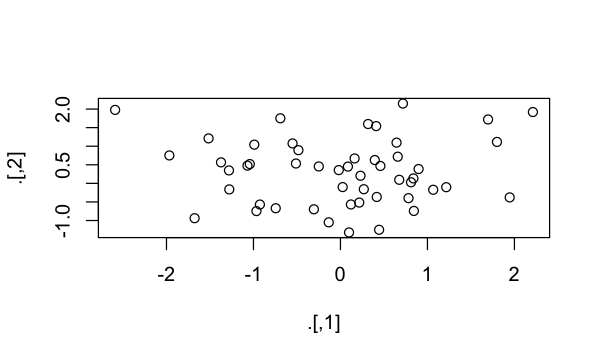

```r
100 %>%
  rnorm %>%
  matrix(ncol = 2) %>%
  plot
```

[[Jump to top]](#jump_to_top)

## nycflights13

To explore the basic data manipulation verbs of dplyr, we'll use `nycflights13::flights`. This data frame contains all 336,776 flights that departed from New York City in 2013. The data comes from the US Bureau of Transportation Statistics, and is documented in `?flights`.

```r
print(flights)
```

```
# A tibble: 336,776 x 19
    year month   day dep_time sched_dep_time dep_delay arr_time sched_arr_time
   <int> <int> <int>    <int>          <int>     <dbl>    <int>          <int>
 1  2013     1     1      517            515         2      830            819
 2  2013     1     1      533            529         4      850            830
 3  2013     1     1      542            540         2      923            850
 4  2013     1     1      544            545        -1     1004           1022
 5  2013     1     1      554            600        -6      812            837
 6  2013     1     1      554            558        -4      740            728
 7  2013     1     1      555            600        -5      913            854
 8  2013     1     1      557            600        -3      709            723
 9  2013     1     1      557            600        -3      838            846
10  2013     1     1      558            600        -2      753            745
# ... with 336,766 more rows, and 11 more variables: arr_delay <dbl>,
#   carrier <chr>, flight <int>, tailnum <chr>, origin <chr>, dest <chr>,
#   air_time <dbl>, distance <dbl>, hour <dbl>, minute <dbl>, time_hour <dttm>
```

```r
# flights  # to see all the columns and more rows
```

[[Jump to top]](#jump_to_top)

## dplyr basics

**dplyr** is a grammar of data manipulation, providing a consistent set of verbs that help you solve the most common data manipulation challenges:

- `filter()` picks cases based on their values.
- `arrange()` changes the ordering of the rows.
- `select()` picks variables based on their names.
- `mutate()` adds new variables that are functions of existing variables
- `summarize()` reduces multiple values down to a single summary.

These six functions provide the verbs for a language of data manipulation. These all combine naturally with `group_by()` which allows you to perform any operation "by group".

All verbs work similarly:

1. The first argument is a data frame.
2. The subsequent arguments describe what to do with the data frame, using the variable names (without quotes).
3. The result is a new data frame.

## Filter rows with `filter()`

`filter()` allows you to subset observations based on their values. The first argument is the name of the data frame. The second and subsequent arguments are the expressions that filter the data frame. For example, we can select all flights on January 1st with:

```r
filter(flights, month == 1, day == 1) %>%
  print
```

```
# A tibble: 842 x 19
    year month   day dep_time sched_dep_time dep_delay arr_time sched_arr_time
   <int> <int> <int>    <int>          <int>     <dbl>    <int>          <int>
 1  2013     1     1      517            515         2      830            819
 2  2013     1     1      533            529         4      850            830
 3  2013     1     1      542            540         2      923            850
 4  2013     1     1      544            545        -1     1004           1022
 5  2013     1     1      554            600        -6      812            837
 6  2013     1     1      554            558        -4      740            728
 7  2013     1     1      555            600        -5      913            854
 8  2013     1     1      557            600        -3      709            723
 9  2013     1     1      557            600        -3      838            846
10  2013     1     1      558            600        -2      753            745
# ... with 832 more rows, and 11 more variables: arr_delay <dbl>,
#   carrier <chr>, flight <int>, tailnum <chr>, origin <chr>, dest <chr>,
#   air_time <dbl>, distance <dbl>, hour <dbl>, minute <dbl>, time_hour <dttm>
```

You can see that I have used `%>% print` at the end. This is only because I am in Jupyter, in RStudio you can skip that part and still get a similar tibble output.

dplyr functions never modify their inputs, so if you want to save the result, you'll need to use the assignment operator, `<-`:

```r
jan1 <- filter(flights, month == 1, day == 1)
```

### Comparisons

R provides the standard suite: `>`, `>=`, `<`, `<=`, `!=` (not equal), and `==` (equal) for performing comparisons. All of these can be used inside `filter()`. For instance the following code will filter out the flights without any departure delay:

```r
flights %>%
  filter(dep_delay <= 0) %>%
  print
```

```
# A tibble: 200,089 x 19
    year month   day dep_time sched_dep_time dep_delay arr_time sched_arr_time
   <int> <int> <int>    <int>          <int>     <dbl>    <int>          <int>
 1  2013     1     1      544            545        -1     1004           1022
 2  2013     1     1      554            600        -6      812            837
 3  2013     1     1      554            558        -4      740            728
 4  2013     1     1      555            600        -5      913            854
 5  2013     1     1      557            600        -3      709            723
 6  2013     1     1      557            600        -3      838            846
 7  2013     1     1      558            600        -2      753            745
 8  2013     1     1      558            600        -2      849            851
 9  2013     1     1      558            600        -2      853            856
10  2013     1     1      558            600        -2      924            917
# ... with 200,079 more rows, and 11 more variables: arr_delay <dbl>,
#   carrier <chr>, flight <int>, tailnum <chr>, origin <chr>, dest <chr>,
#   air_time <dbl>, distance <dbl>, hour <dbl>, minute <dbl>, time_hour <dttm>
```

### Logical operators

We can provide multiple comparisons to `filter()`. For this you'll need to use Boolean operators: `&` is "and", `|` is "or", and `!` is "not". Figure below shows a complete set of Boolean operations.

[figure not shown]

The following code finds all flights that departed in November **or** December:

```r
flights %>%
  filter(month == 11 | month == 12) %>%
  print
```

```
# A tibble: 55,403 x 19
    year month   day dep_time sched_dep_time dep_delay arr_time sched_arr_time
   <int> <int> <int>    <int>          <int>     <dbl>    <int>          <int>
 1  2013    11     1        5           2359         6      352            345
 2  2013    11     1       35           2250       105      123           2356
 3  2013    11     1      455            500        -5      641            651
 4  2013    11     1      539            545        -6      856            827
 5  2013    11     1      542            545        -3      831            855
 6  2013    11     1      549            600       -11      912            923
 7  2013    11     1      550            600       -10      705            659
 8  2013    11     1      554            600        -6      659            701
 9  2013    11     1      554            600        -6      826            827
10  2013    11     1      554            600        -6      749            751
# ... with 55,393 more rows, and 11 more variables: arr_delay <dbl>,
#   carrier <chr>, flight <int>, tailnum <chr>, origin <chr>, dest <chr>,
#   air_time <dbl>, distance <dbl>, hour <dbl>, minute <dbl>, time_hour <dttm>
```

Alternatively we could use the following syntax:

> `filter(flights, month %in% c(11, 12))`

Whenever you start using complicated, multi-part expressions in `filter()`, consider making them explicit variables instead. That makes it much easier to check your work. You'll learn how to create new variables shortly.

### Missing values

One important feature of R that can make comparison tricky is missing value, or `NA` ("Not Available"). `NA` represents an unknown value so missing values are "contagious": almost any operation involving an unknown value will also be unknown:

```r
NA > 5
```

<NA>

```r
10 == NA
```

<NA>

```r
NA + 10
```

<NA>

```r
NA / 2
```

<NA>

```r
NA == NA
```

<NA>

It's easiest to understand why this is true with a bit more context:

```r
# Let x be Mary's age. We don't know how old she is.
x <- NA

# Let y be John's age. We don't know how old he is.
y <- NA

# Are John and Mary the same age?
x == y
```

<NA>

We don't know!

Use `is.na()` to determine if a value is missing

```r
is.na(x)
```

TRUE

`filter()` only includes rows where the condition is `TRUE`; it excludes both `FALSE` and `NA` values. If you want to preserve missing values, ask for them explicitly:

```r
(df <- tibble(x = c(1, NA, 3)))
```

| x |
| --- |
| 1 |
| NA |
| 3 |

```r
filter(df, x > 1)
```

| x |
| --- |
| 3 |

```r
filter(df, is.na(x) | x > 1)
```

| x |
| --- |
| NA |
| 3 |

### Exercise 1

Find all flights that

1. Had an arrival delay of two or more hours
2. Flew to Houston (IAH or HOU)
3. Were operated by United, American, or Delta (hint: use `airline` dataset to get the two-character carrier codes)
4. Departed in summer (July, August, and September)
5. Arrived more than two hours late, but didn't leave late
6. Departed by at least an hour delay, but made up over 30 minutes in flight
7. Departed between midnight and 6am (inclusive)

```r
# Your answer goes here
```

### Exercise 2

Another useful dplyr filtering helper is `between()`. What does it do? Can you use it to simplify the code needed to answer the previous challenge, part 4?

```r
# Your answer goes here
```

### Exercise 3

How many flights have a missing `dep_time`? What other variables are missing? What might these rows represent?

```r
# Your answer goes here
```

[[Jump to top]](#jump_to_top)

## Arrange rows with `arrange()`

`arrange()` works similarly to `filter()` except that instead of selecting rows, it does what it claims it does: changes their order. It takes a data frame and a set of column names (or more complicated expressions) to order by. If you provide more than one column name, each additional column will be used to break ties in the values of preceding columns:

```r
arrange(flights, year, month, day) %>%
  print
```

```
# A tibble: 336,776 x 19
    year month   day dep_time sched_dep_time dep_delay arr_time sched_arr_time
   <int> <int> <int>    <int>          <int>     <dbl>    <int>          <int>
 1  2013     1     1      517            515         2      830            819
 2  2013     1     1      533            529         4      850            830
 3  2013     1     1      542            540         2      923            850
 4  2013     1     1      544            545        -1     1004           1022
 5  2013     1     1      554            600        -6      812            837
 6  2013     1     1      554            558        -4      740            728
 7  2013     1     1      555            600        -5      913            854
 8  2013     1     1      557            600        -3      709            723
 9  2013     1     1      557            600        -3      838            846
10  2013     1     1      558            600        -2      753            745
# ... with 336,766 more rows, and 11 more variables: arr_delay <dbl>,
#   carrier <chr>, flight <int>, tailnum <chr>, origin <chr>, dest <chr>,
#   air_time <dbl>, distance <dbl>, hour <dbl>, minute <dbl>, time_hour <dttm>
```

Use `desc()` to re-order by a column in descending order:

```r
arrange(flights, desc(dep_delay)) %>%
  print
```

```
# A tibble: 336,776 x 19
    year month   day dep_time sched_dep_time dep_delay arr_time sched_arr_time
   <int> <int> <int>    <int>          <int>     <dbl>    <int>          <int>
 1  2013     1     9      641            900      1301     1242           1530
 2  2013     6    15     1432           1935      1137     1607           2120
 3  2013     1    10     1121           1635      1126     1239           1810
 4  2013     9    20     1139           1845      1014     1457           2210
 5  2013     7    22      845           1600      1005     1044           1815
 6  2013     4    10     1100           1900       960     1342           2211
 7  2013     3    17     2321            810       911      135           1020
 8  2013     6    27      959           1900       899     1236           2226
 9  2013     7    22     2257            759       898      121           1026
10  2013    12     5      756           1700       896     1058           2020
# ... with 336,766 more rows, and 11 more variables: arr_delay <dbl>,
#   carrier <chr>, flight <int>, tailnum <chr>, origin <chr>, dest <chr>,
#   air_time <dbl>, distance <dbl>, hour <dbl>, minute <dbl>, time_hour <dttm>
```

Missing values are always sorted at the end:

```r
df <- tibble(x = c(5, 6, 2, NA))
arrange(df, x)
```

| x |
| --- |
| 2 |
| 5 |
| 6 |
| NA |

```r
arrange(df, desc(x))
```

| x |
| --- |
| 6 |
| 5 |
| 2 |
| NA |

### Exercise 4

1) How could you use `arrange()` to sort all missing values to the start? (Hint: use `is.na()` and apply your answer to the `df` dataframe we created above).

2) Apply this answer to `flights` dataset to list the canceled flights first (assuming `NA` for `dep_delay` means the flight was canceled) and then show other flights starting with the ones with large `dep_delay` in a descending order.

```r
# Your answer goes here
```

[[Jump to top]](#jump_to_top)

## Select columns with `select()`

It's not uncommon to get datasets with hundreds or even thousands of variables. In this case, the first challenge is often narrowing in on the variables you're actually interested in. `select()` allows you to do that:

```r
# Select columns by name
select(flights, year, month, day) %>%
  print
```

```
# A tibble: 336,776 x 3
    year month   day
   <int> <int> <int>
 1  2013     1     1
 2  2013     1     1
 3  2013     1     1
 4  2013     1     1
 5  2013     1     1
 6  2013     1     1
 7  2013     1     1
 8  2013     1     1
 9  2013     1     1
10  2013     1     1
# ... with 336,766 more rows
```

```r
# Select all colon between year and day (inclusive)
select(flights, year:day) %>%
  print
```

```
# A tibble: 336,776 x 3
    year month   day
   <int> <int> <int>
 1  2013     1     1
 2  2013     1     1
 3  2013     1     1
 4  2013     1     1
 5  2013     1     1
 6  2013     1     1
 7  2013     1     1
 8  2013     1     1
 9  2013     1     1
10  2013     1     1
# ... with 336,766 more rows
```

```r
# Select all columns except those from year to day (inclusive)
select(flights, -(year:day)) %>%
  print
```

```
# A tibble: 336,776 x 16
   dep_time sched_dep_time dep_delay arr_time sched_arr_time arr_delay carrier
      <int>          <int>     <dbl>    <int>          <int>     <dbl> <chr>
 1      517            515         2      830            819        11 UA
 2      533            529         4      850            830        20 UA
 3      542            540         2      923            850        33 AA
 4      544            545        -1     1004           1022       -18 B6
 5      554            600        -6      812            837       -25 DL
 6      554            558        -4      740            728        12 UA
 7      555            600        -5      913            854        19 B6
 8      557            600        -3      709            723       -14 EV
 9      557            600        -3      838            846        -8 B6
10      558            600        -2      753            745         8 AA
# ... with 336,766 more rows, and 9 more variables: flight <int>,
#   tailnum <chr>, origin <chr>, dest <chr>, air_time <dbl>, distance <dbl>,
#   hour <dbl>, minute <dbl>, time_hour <dttm>
```

There are a number of helper functions you can use within `select()`:

- `starts_with("abc")`: matches names that begin with "abc".
- `ends_with("xyz")`: matches names that end with "xyz".
- `contains("ijk")`: matches names that contain "ijk".
- `num_range("x", 1:3)`: matches `x1`, `x2` and `x3`.
- `everything()`: useful for bringing a few variables to the beginning of the dataframe and still want to keep everything else at the end.

See `?select` for more details.

`select()` can be used to rename variables (e.g., `select(flights, y = year)`), but it's rarely useful because it drops all of the variables not explicitly mentioned. Instead, use `rename()`, which is a variant of `select()` that keeps all the variables that aren't explicitly mentioned:

```r
rename(flights, y = year, tail_num = tailnum) %>%
  print
```

```
# A tibble: 336,776 x 19
       y month   day dep_time sched_dep_time dep_delay arr_time sched_arr_time
   <int> <int> <int>    <int>          <int>     <dbl>    <int>          <int>
 1  2013     1     1      517            515         2      830            819
 2  2013     1     1      533            529         4      850            830
 3  2013     1     1      542            540         2      923            850
 4  2013     1     1      544            545        -1     1004           1022
 5  2013     1     1      554            600        -6      812            837
 6  2013     1     1      554            558        -4      740            728
 7  2013     1     1      555            600        -5      913            854
 8  2013     1     1      557            600        -3      709            723
 9  2013     1     1      557            600        -3      838            846
10  2013     1     1      558            600        -2      753            745
# ... with 336,766 more rows, and 11 more variables: arr_delay <dbl>,
#   carrier <chr>, flight <int>, tail_num <chr>, origin <chr>, dest <chr>,
#   air_time <dbl>, distance <dbl>, hour <dbl>, minute <dbl>, time_hour <dttm>
```

```r
# everything() example
select(flights, time_hour, aritime = air_time, everything()) %>%
  print
```

```
# A tibble: 336,776 x 19
   time_hour           aritime  year month   day dep_time sched_dep_time
   <dttm>                <dbl> <int> <int> <int>    <int>          <int>
 1 2013-01-01 05:00:00     227  2013     1     1      517            515
 2 2013-01-01 05:00:00     227  2013     1     1      533            529
 3 2013-01-01 05:00:00     160  2013     1     1      542            540
 4 2013-01-01 05:00:00     183  2013     1     1      544            545
 5 2013-01-01 06:00:00     116  2013     1     1      554            600
 6 2013-01-01 05:00:00     150  2013     1     1      554            558
 7 2013-01-01 06:00:00     158  2013     1     1      555            600
 8 2013-01-01 06:00:00      53  2013     1     1      557            600
 9 2013-01-01 06:00:00     140  2013     1     1      557            600
10 2013-01-01 06:00:00     138  2013     1     1      558            600
# ... with 336,766 more rows, and 12 more variables: dep_delay <dbl>,
#   arr_time <int>, sched_arr_time <int>, arr_delay <dbl>, carrier <chr>,
#   flight <int>, tailnum <chr>, origin <chr>, dest <chr>, distance <dbl>,
#   hour <dbl>, minute <dbl>
```

### Exercise 5

Brainstorm as many ways as possible to select `dep_time`, `dep_delay`, `arr_time`, and `arr_delay` from `flights`.

```r
# Your answer goes here
```

### Exercise 6

What happens if you include the name of a variable multiple times in a `select()` call?

```r
# Your answer goes here
```

### Exercise 7

Does the result of running the following code surprise you? How do the select helpers deal with case by default? How can you change that default?

```r
select(flights, contains("TIME")) %>%
  print
```

```
# A tibble: 336,776 x 6
   dep_time sched_dep_time arr_time sched_arr_time air_time time_hour
      <int>          <int>    <int>          <int>    <dbl> <dttm>
 1      517            515      830            819      227 2013-01-01 05:00:00
 2      533            529      850            830      227 2013-01-01 05:00:00
 3      542            540      923            850      160 2013-01-01 05:00:00
 4      544            545     1004           1022      183 2013-01-01 05:00:00
 5      554            600      812            837      116 2013-01-01 06:00:00
 6      554            558      740            728      150 2013-01-01 05:00:00
 7      555            600      913            854      158 2013-01-01 06:00:00
 8      557            600      709            723       53 2013-01-01 06:00:00
 9      557            600      838            846      140 2013-01-01 06:00:00
10      558            600      753            745      138 2013-01-01 06:00:00
# ... with 336,766 more rows
```

[[Jump to top]](#jump_to_top)

## Add new variables with `mutate()`

Besides selecting sets of existing columns, it's often useful to add new columns that are functions of existing columns. That's the job of `mutate()`.

`mutate()` always adds new columns at the end of your dataset, but doesn't change the original dataframe. If you want to keep the outcome of `mutate()`, or any of the other functions we discussed above, assign the output to a new or existing object.

```r
# Starting with a smaller number of columns
flights_sml <- select(flights,
                      year:day,
                      ends_with("delay"),
                      distance,
                      air_time
                     )

print(flights_sml)
```

```
# A tibble: 336,776 x 7
    year month   day dep_delay arr_delay distance air_time
   <int> <int> <int>     <dbl>     <dbl>    <dbl>    <dbl>
 1  2013     1     1         2        11     1400      227
 2  2013     1     1         4        20     1416      227
 3  2013     1     1         2        33     1089      160
 4  2013     1     1        -1       -18     1576      183
 5  2013     1     1        -6       -25      762      116
 6  2013     1     1        -4        12      719      150
 7  2013     1     1        -5        19     1065      158
 8  2013     1     1        -3       -14      229       53
 9  2013     1     1        -3        -8      944      140
10  2013     1     1        -2         8      733      138
# ... with 336,766 more rows
```

```r
mutate(flights_sml,
       gain = dep_delay - arr_delay,
       speed = distance / air_time * 60
      ) %>%
  print
```

```
# A tibble: 336,776 x 9
    year month   day dep_delay arr_delay distance air_time  gain speed
   <int> <int> <int>     <dbl>     <dbl>    <dbl>    <dbl> <dbl> <dbl>
 1  2013     1     1         2        11     1400      227    -9  370.
 2  2013     1     1         4        20     1416      227   -16  374.
 3  2013     1     1         2        33     1089      160   -31  408.
 4  2013     1     1        -1       -18     1576      183    17  517.
 5  2013     1     1        -6       -25      762      116    19  394.
 6  2013     1     1        -4        12      719      150   -16  288.
 7  2013     1     1        -5        19     1065      158   -24  404.
 8  2013     1     1        -3       -14      229       53    11  259.
 9  2013     1     1        -3        -8      944      140     5  405.
10  2013     1     1        -2         8      733      138   -10  319.
# ... with 336,766 more rows
```

Alternatively we could've used our piping skills:

```r
flights %>%
  select(year:day,
         ends_with("delay"),
         distance,
         air_time
        ) %>%
  mutate(gain = dep_delay - arr_delay,
         speed = distance / air_time * 60) %>%
  print
```

```
# A tibble: 336,776 x 9
    year month   day dep_delay arr_delay distance air_time  gain speed
   <int> <int> <int>     <dbl>     <dbl>    <dbl>    <dbl> <dbl> <dbl>
 1  2013     1     1         2        11     1400      227    -9  370.
 2  2013     1     1         4        20     1416      227   -16  374.
 3  2013     1     1         2        33     1089      160   -31  408.
 4  2013     1     1        -1       -18     1576      183    17  517.
 5  2013     1     1        -6       -25      762      116    19  394.
 6  2013     1     1        -4        12      719      150   -16  288.
 7  2013     1     1        -5        19     1065      158   -24  404.
 8  2013     1     1        -3       -14      229       53    11  259.
 9  2013     1     1        -3        -8      944      140     5  405.
10  2013     1     1        -2         8      733      138   -10  319.
# ... with 336,766 more rows
```

Note that you can refer to columns that you've just created:

```r
mutate(flights_sml,
       gain = dep_delay - arr_delay,
       hours = air_time / 60,
       gain_per_hour = gain / hours
      ) %>%
  print
```

```
# A tibble: 336,776 x 10
    year month   day dep_delay arr_delay distance air_time  gain hours
   <int> <int> <int>     <dbl>     <dbl>    <dbl>    <dbl> <dbl> <dbl>
 1  2013     1     1         2        11     1400      227    -9 3.78
 2  2013     1     1         4        20     1416      227   -16 3.78
 3  2013     1     1         2        33     1089      160   -31 2.67
 4  2013     1     1        -1       -18     1576      183    17 3.05
 5  2013     1     1        -6       -25      762      116    19 1.93
 6  2013     1     1        -4        12      719      150   -16 2.5
 7  2013     1     1        -5        19     1065      158   -24 2.63
 8  2013     1     1        -3       -14      229       53    11 0.883
 9  2013     1     1        -3        -8      944      140     5 2.33
10  2013     1     1        -2         8      733      138   -10 2.3
# ... with 336,766 more rows, and 1 more variable: gain_per_hour <dbl>
```

### Exercise 8

Currently `dep_time` and `sched_dep_time` are convenient to look at, but hard to compute with because they're not really continuous numbers. Convert them to a more convenient representation of number of minutes since midnight.

```r
# Your answer goes here
```

[[Jump to top]](#jump_to_top)